# presentation slides

## Investigation Overview

I scraped and cleaned this dataset myself from realestate.com.au website. This website is the main source of property advertisement in Australia. My goal is to get an understanding of the Australian property market by looking at the records or sold property during the last 10 years. I aim to answer some useful questions about investing in the property market including :

WHEN should I buy a property?  
WHAT should I buy? What type of property? House, Townhouse, Unit or Apartment?  
WHERE should I buy? Which suburb has the most potential for growth?

## Dataset Overview

The dataset is a list of all individual proeprties sold in the lifespan of the realestate.com.au website. As the number of sold properties accross Australia is too large for the purposes of this project, I scraped and analyzed the data for the state of Victoria only. The final cleaned dataset has over 700000 rows. It comprises of address, agent and agency in charge of selling, number of bedrooms, bathrooms and car parks, price , sold date and suburb.

There are a number of properties without a price, I kept them in the dataset to have the number of sold properties but excluded them from price analysis.

### Property type distribution

As we can see in the chart, the top 5 property types comprise the majority of all property types. Excluding the Residential land, the other 4 are all residential property types that we are looking for.

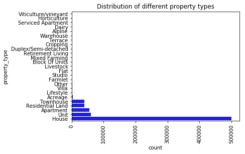

```python
sb.countplot(data=clean, y='property_type',color='Blue', order=clean.property_type.value_counts().sort_values().index)
plt.xticks(rotation=90);
plt.title('Distribution of different property types');
```

### Price distribution abnormality

By looking at the price distribution of all properties, we can see the is a gap at the 800000 price range, as it turns out this is due to tax cuts by the government. The threshhold for tax cuts is at 700000 and most people choose properties below this price, if they were to pass this threshhold they might as well go well above to get better value for their money. Therefor we have a huge gap between 700000 and 800000 price range.

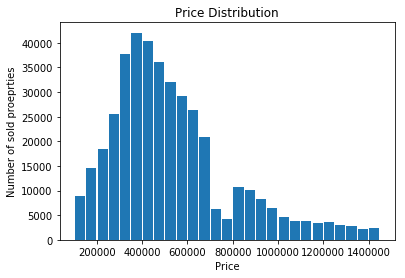

```python
plt.hist(data=clean, x ='price', bins=np.arange(100000, 1500000, 50000), rwidth=.9);
plt.xlabel('Price')
plt.ylabel('Number of sold proeprties')
plt.title('Price Distribution');
```

### WHEN is the best time to buy?

By looking at the median and average price of sold proeprties from 2008 to the end of 2018 categorised by the month, we can see that January is by far the best month to buy property.

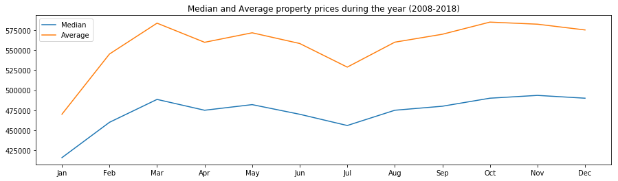

```python
tt1 = clean[(clean.price>0)].query('sold_date>"2007-12-31" & sold_date<"2019-01-01"').copy()
fig = plt.figure(figsize=(15, 4))
ax = fig.add_subplot(111)
ax.plot(tt1.groupby(['month']).price.median());
ax.plot(tt1.groupby(['month']).price.mean());
plt.title('Median and Average property prices during the year (2008-2018)')
plt.legend(['Median','Average'])
plt.xticks(np.arange(1,13,1),['Jan','Feb','Mar','Apr','May','Jun','Jul','Aug','Sep','Oct','Nov','Dec']);
```

### WHAT type of property is best to buy?

To answer this question I look the the median price of the 4 major proeprty types (House, Townhouse, Unit, Apartment) during the last 10 years. By looking at the chart below we can see that Apartments have had the least and Townhouses and Houses have had the most growth during the years with Townhouses having the highest median price.

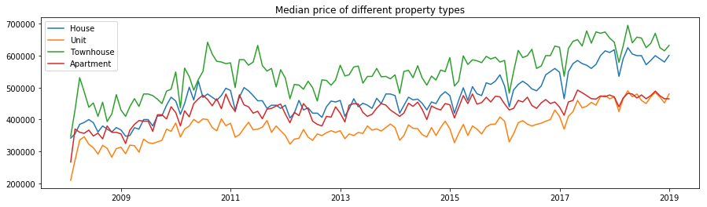

```python
tt1 = clean[(clean.price>0) & (clean.property_type=='House')].query('sold_date>"2007-12-31" & sold_date<"2019-01-01"').copy()
tt2 = clean[(clean.price>0) & (clean.property_type=='Unit')].query('sold_date>"2007-12-31" & sold_date<"2019-01-01"').copy()
tt3 = clean[(clean.price>0) & (clean.property_type=='Townhouse')].query('sold_date>"2007-12-31" & sold_date<"2019-01-01"').copy()
tt4 = clean[(clean.price>0) & (clean.property_type=='Apartment')].query('sold_date>"2007-12-31" & sold_date<"2019-01-01"').copy()
grouped1 = tt1.set_index('sold_date').groupby(pd.TimeGrouper('M'))
grouped2 = tt2.set_index('sold_date').groupby(pd.TimeGrouper('M'))
grouped3 = tt3.set_index('sold_date').groupby(pd.TimeGrouper('M'))
grouped4 = tt4.set_index('sold_date').groupby(pd.TimeGrouper('M'))
fig = plt.figure(figsize=(15, 4))
ax = fig.add_subplot(111)
ax.plot(grouped1.price.median().dropna());
ax.plot(grouped2.price.median().dropna());
ax.plot(grouped3.price.median().dropna());
ax.plot(grouped4.price.median().dropna());
plt.title('Median price of different property types')
plt.legend(['House','Unit', 'Townhouse','Apartment']);
```

### How big the property should be?

Now that we know Houses and Townhouses have the best growth potential, let's look at the different property sizes, I'll look at the most common sizes which are 2, 3 and 4 bedroom properties.  
We can see that Townhouses and Units have had relatively more growth in the 2 bedrooms section.  
It's in the 3 bedrooms section that the proeprty types really show their difference and the lines detatch from each other. Apartments with the highest median price and then comes Townhouses.  
In the 4 bedrooms section there is volatility in Apartments since there are relatively not a lot of 4 bedrooms apartments being sold compared to the others. Townhouses are the second most expensive type in this section and are showing slightly faster growth compared to the other 3.  
Comparing all charts, in my opinion 2 and 4 bedroom Townhouses are good choices for investment.

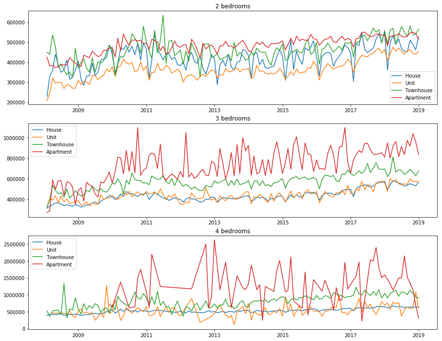

```python
tt1 = clean[(clean.price>0) & (clean.property_type=='House')].query('sold_date>"2007-12-31" & sold_date<"2019-01-01"').copy()
tt2 = clean[(clean.price>0) & (clean.property_type=='Unit')].query('sold_date>"2007-12-31" & sold_date<"2019-01-01"').copy()
tt3 = clean[(clean.price>0) & (clean.property_type=='Townhouse')].query('sold_date>"2007-12-31" & sold_date<"2019-01-01"').copy()
tt4 = clean[(clean.price>0) & (clean.property_type=='Apartment')].query('sold_date>"2007-12-31" & sold_date<"2019-01-01"').copy()
grouped1 = tt1[tt1.beds==2].set_index('sold_date').groupby(pd.TimeGrouper('M'))
grouped2 = tt2[tt2.beds==2].set_index('sold_date').groupby(pd.TimeGrouper('M'))
grouped3 = tt3[tt3.beds==2].set_index('sold_date').groupby(pd.TimeGrouper('M'))
grouped4 = tt4[tt4.beds==2].set_index('sold_date').groupby(pd.TimeGrouper('M'))
fig = plt.figure(figsize=(15, 12))
ax = fig.add_subplot(311)
ax.plot(grouped1.price.median().dropna());
ax.plot(grouped2.price.median().dropna());
ax.plot(grouped3.price.median().dropna());
ax.plot(grouped4.price.median().dropna());
plt.title('2 bedrooms')
plt.legend(['House','Unit', 'Townhouse', 'Apartment']);
grouped1 = tt1[tt1.beds==3].set_index('sold_date').groupby(pd.TimeGrouper('M'))
grouped2 = tt2[tt2.beds==3].set_index('sold_date').groupby(pd.TimeGrouper('M'))
grouped3 = tt3[tt3.beds==3].set_index('sold_date').groupby(pd.TimeGrouper('M'))
grouped4 = tt4[tt4.beds==3].set_index('sold_date').groupby(pd.TimeGrouper('M'))
az = fig.add_subplot(312)
az.plot(grouped1.price.median().dropna());
az.plot(grouped2.price.median().dropna());
az.plot(grouped3.price.median().dropna());
az.plot(grouped4.price.median().dropna());
plt.title('3 bedrooms')
plt.legend(['House','Unit', 'Townhouse', 'Apartment']);
grouped1 = tt1[tt1.beds==4].set_index('sold_date').groupby(pd.TimeGrouper('M'))
grouped2 = tt2[tt2.beds==4].set_index('sold_date').groupby(pd.TimeGrouper('M'))
grouped3 = tt3[tt3.beds==4].set_index('sold_date').groupby(pd.TimeGrouper('M'))
grouped4 = tt4[tt4.beds==4].set_index('sold_date').groupby(pd.TimeGrouper('M'))
ac = fig.add_subplot(313)
ac.plot(grouped1.price.median().dropna());
ac.plot(grouped2.price.median().dropna());
ac.plot(grouped3.price.median().dropna());
ac.plot(grouped4.price.median().dropna());
plt.title('4 bedrooms')
plt.legend(['House','Unit', 'Townhouse', 'Apartment']);
```

### WHERE? Which suburb shows the most potential?

There are over 2000 suburbs in the state of Victoria, Australia. Most of them are countryside suburbs with farms and far awat from major cities.  
To compare the suburbs with each other first I picked the top 100 suburbs with the most number of Houses sold, and the top 50 suburbs for the other 3 property types.  
Then I calculated the difference in property median price each year and averaged the differences while giving more weight to recent years.  
Based on the visualizations, buying a 2 bedroom Townhouse in Kew in January has a high chance of being a very good investment!

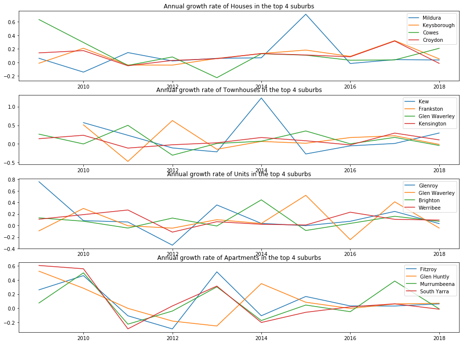

```python
fig=plt.figure(figsize=(16,12))
ax = fig.add_subplot(411)
ax.plot(subg.house_growth[subg.sort_values(by='h_mean',ascending=False).index[0]][1:])
ax.plot(subg.house_growth[subg.sort_values(by='h_mean',ascending=False).index[1]][1:])
ax.plot(subg.house_growth[subg.sort_values(by='h_mean',ascending=False).index[2]][1:])
ax.plot(subg.house_growth[subg.sort_values(by='h_mean',ascending=False).index[3]][1:])
plt.title('Annual growth rate of Houses in the top 4 suburbs')
plt.legend([subg.sort_values(by='h_mean',ascending=False).name.values[0],subg.sort_values(by='h_mean',ascending=False).name.values[1],
            subg.sort_values(by='h_mean',ascending=False).name.values[2],subg.sort_values(by='h_mean',ascending=False).name.values[3]])
az = fig.add_subplot(412)
az.plot(subg.townhouse_growth[subg.sort_values(by='t_mean',ascending=False).index[0]][1:])
az.plot(subg.townhouse_growth[subg.sort_values(by='t_mean',ascending=False).index[1]][1:])
az.plot(subg.townhouse_growth[subg.sort_values(by='t_mean',ascending=False).index[2]][1:])
az.plot(subg.townhouse_growth[subg.sort_values(by='t_mean',ascending=False).index[3]][1:])
plt.title('Annual growth rate of Townhouses in the top 4 suburbs')
plt.legend([subg.sort_values(by='t_mean',ascending=False).name.values[0],subg.sort_values(by='t_mean',ascending=False).name.values[1],
            subg.sort_values(by='t_mean',ascending=False).name.values[2],subg.sort_values(by='t_mean',ascending=False).name.values[3]])
az = fig.add_subplot(413)
az.plot(subg.unit_growth[subg.sort_values(by='u_mean',ascending=False).index[0]][1:])
az.plot(subg.unit_growth[subg.sort_values(by='u_mean',ascending=False).index[1]][1:])
az.plot(subg.unit_growth[subg.sort_values(by='u_mean',ascending=False).index[2]][1:])
az.plot(subg.unit_growth[subg.sort_values(by='u_mean',ascending=False).index[3]][1:])
plt.title('Annual growth rate of Units in the top 4 suburbs')
plt.legend([subg.sort_values(by='u_mean',ascending=False).name.values[0],subg.sort_values(by='u_mean',ascending=False).name.values[1],
            subg.sort_values(by='u_mean',ascending=False).name.values[2],subg.sort_values(by='u_mean',ascending=False).name.values[3]])
az = fig.add_subplot(414)
az.plot(subg.apartment_growth[subg.sort_values(by='a_mean',ascending=False).index[0]][1:])
az.plot(subg.apartment_growth[subg.sort_values(by='a_mean',ascending=False).index[1]][1:])
az.plot(subg.apartment_growth[subg.sort_values(by='a_mean',ascending=False).index[2]][1:])
az.plot(subg.apartment_growth[subg.sort_values(by='a_mean',ascending=False).index[3]][1:])
plt.title('Annual growth rate of Apartments in the top 4 suburbs')
plt.legend([subg.sort_values(by='a_mean',ascending=False).name.values[0],subg.sort_values(by='a_mean',ascending=False).name.values[1],
            subg.sort_values(by='a_mean',ascending=False).name.values[2],subg.sort_values(by='a_mean',ascending=False).name.values[3]]);
```